# Poisson Gleichung auf dem Rechteck

## Numerische Diskretisierung mit Finite-Differenzenverfahren

### Implementierung der Randwertaufgabe für Dirichlet-Randbedingungen

In diesem Skript wird stationäre Diffusion mithilfe der Poissongleichung auf einem rechteckigem Gebiet mithilfe der Finiten Differenzen Methode für Dirichlet Randwertprobleme implementiert: $$-a\Delta u=f \ \ \mbox{in} \ \ D=(0,X_{end})\times (0,Y_{end}), $$ $$ u(x)=g(x)\ \ \mbox{auf} \ \partial D \quad \qquad.$$
Die Dirichlet Randbedingungen sagen aus, dass die Werter einer Funktion $u(x,y)$ mit $x, y \in D$ am Rand $x, y \in \partial D$ durch eine andere Funktion $g(x)$ gegeben sind.

##### Definition der Quelldichtefunktion f der rechten Seite der Poissongleichung

```matlab
function wert=Quellfunktion(x,y)
  if sqrt((x.-3.25).^2+(y.-3).^2)<=0.35 wert=1;
    else wert=0;
  endif
endfunction
```

##### Definition des rechteckigen Gebietes

Hier wird das Gebiet $D$ durch die Endpunkte der Intervalle $X_{end}, Y_{end}$ festgelegt und die konstante Schrittweite $h=h_x=h_y$ durch die Anzahl $N$ der inneren X-Punkte festgelegt, die (inneren) Gitterpunkte sind wie folgt definiert: $$\{(x_i,y_j), \quad i=1, \ldots , N,\ x_0=0, \ x_{N+1}=X_{end}, \ \ j=1, \ldots , M,\ y_0=0,\ Y_{M+1}\stackrel{\approx}{<}Y_{end}\}.$$

(Anzahl von Y-Punkte $M$ ist anhand von der festgelegten Gittergröße $h=\frac{X_{end}-x_0}{N+1}$ bestimmt, sodass die Punkte der oberen Reihe nicht aus $D$ raustreten).

```matlab
%Implementation grundlegender Parameter
%definiere Gebiet D
  xend=8;
  yend=5;

N=80;%Anzahl von X-Punkten

hx=xend/(N+1); %Schrittweite in x-Richtung
hy=hx; %äquidistantes Gitter, da hy=hx
M=floor((yend/hy))-1;   %floor rundet ab auf die nächste Ganzzahl aus 4,98 wird 4.
[x,y]=meshgrid(hx:hx:xend-hx,hy:hy:yend-hy); %Koordinatenmatrix der Gitterpunkte
```

#### Implementation verschiedener Dirichlet Randbedingungen

Versuch 1: alles Konstant gleich </br> Versuch 2: oben 1, unten 0, links & rechts aufsteigend von 0 nach 1</br> Versuch 3: Wie von Fr. Hundertmark vorgegeben

```matlab
%-------------------------------------------
%RANDBEDINGUNGEN
%-------------------------------------------
versuch = 3;
if (versuch == 1)
    %Dirichlet RB Versuch 1:
function wert = wert_unten()
  wert = 0.5;
endfunction

function wert = wert_oben()
  wert = 0.5;
endfunction

function wert = wert_links(i,j,M)
  wert = 0.5;
endfunction

function wert = wert_rechts(i,j,M)
  wert = 0.5;
endfunction
%-------------------------------------------
endif
if(versuch == 2)
    %Dirichlet RB Versuch 2:
function wert=wert_unten()
  wert = 0;
endfunction

function wert=wert_oben()
  wert =1;
endfunction

    function wert=wert_links(j,i,M); % i,j gibt an wo man sich am Rand befindet,M gibt an bis wohin j maximal läuft
    ex=2; %Bestimmung des Exponentens -> ändert Form des Randes / Anstieg der Randwerte
    % i ist 1
    % j geht von 1 bis M
    % von 1/M bis 1 in M schritten
    wert = (j/M)^ex; %gibt Funktionswerte des Rands an
    endfunction

    function wert=wert_rechts(j,i,M);
    ex=2;
    % i ist  N
    % j geht von 1 bis M
    % von 0 bis 1 in M schritten
    wert = (j/M)^ex;
    endfunction
endif
%-------------------------------------------
if(versuch == 3)
    %Dirichlet RB Versuch 3:
function wert=wert_unten()
  wert = -0.01;
endfunction

function wert=wert_oben()
  wert = 0.01;
endfunction

function wert=wert_links(i,j,M)
  wert = 0.01;
endfunction

function wert=wert_rechts(i,j,M)
  wert = 0.01;
endfunction
%-------------------------------------------
endif
```

#### Implementation der blocktridiogonalen Systemmatrix $A_h=:BB\in {\mathbb R}^{NM\times NM}$

Diese hat nur auf der Diagonale, auf den beiden Nebendiagonalen und auf der N-ten und der -N-ten Nebendiagonale Einträge.  
\begin{eqnarray} A_h=\frac{-1}{h^2}\begin{pmatrix} B&I& &\ldots &0\\ I & B& I &&\vdots\\\vdots & \ddots &\ddots&\ddots &\\0& &\ldots& I&B\end{pmatrix}\end{eqnarray} mit Diagonalblock \begin{eqnarray} B=\begin{pmatrix} -4& 1& 0 & \ldots &0 \\ 1 & -4& 1& \ldots &0\\ \vdots&\ddots&\ddots&\ddots & 1\\0&\ldots &0& 1&-4\end{pmatrix} \end{eqnarray} mit $B\in {\mathbb R}^{N\times N}$  
$I$= Einheitsmatrix auf Nebendiagonalen  
$I\in {\mathbb R}^{N\times N}$

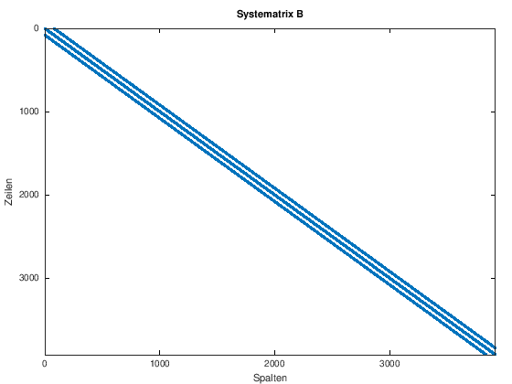

```matlab
%konstanter Diffusionskoeffizient
a=1.0;
%--------------------------


% Systemmatrix A_h von Dirichlet
%-------------------------------------------
  Vec1=ones(N*M,1); % erzeugt vektor der  Laenge N*M % erstellt Hauptdiagonale
  BB=diag(-4.*Vec1,0)+diag(ones(N*M-1,1),1)+ diag(ones(N*M-1,1),-1)+diag(ones(N*(M-1),1),N)+diag(ones(N*(M-1),1),-N);
%Systemmatrix N^2xM^2 (Größe der Gesamtmatrix) mit -4 auf der Diagonale und 1 auf den Nebendiagonalen und 1 auf den N und -N-ter Nebendiagonale
% Größe der einzelnen Blöcke ist NxM

%Korrektur der Matrix (Blockdiagonalitaet) aus einser der Nebendiagonalen werden Nuller
  for  i=1:(M-1)
      BB(i*N+1,i*N)=0;
      BB(i*N,i*N+1)=0;
  endfor


%-------------------------------------------
% Matrix mit Diffkoeff/h^2 multiplizieren
%-------------------------------------------
  BB=BB*a/hx^2;


  %Matrixdarstellung - optional
  %-----------------------------
  figure (11);
  %surface (BB);
  spy (BB);
  xlabel("Spalten")
  ylabel("Zeilen")
  zlabel("Matrix B")
  title ("Systematrix B");
```

### Definition der rechten Seite

Definiere die Matrix $f_{i,j}=f(x_i,y_j)$ der rechten Seite der Poissongleichung.

Hier sollen später die Beiträge aus den inhomogener Randbedingungen implementiert werden.

Die Matrix $f^T \in {\mathbb R}^{N\times M}$ wird in Vektor $\vec{f}_h=:b \in {\mathbb R}^{NM}$ spaltenweise umgeordnet. (Siehe Befehl 'reshape'.)

[figure not shown]

```matlab
%rechte Seite des Systems von Dirichlet
    clear f;
for i=1:N
 for j=1:M
   f(j,i)=1*Quellfunktion(x(j,i),y(j,i)); %für jeden Punkt wird Funktionswert definiert, der auf rechten Seite ausgegeben wird

   %Dirichlet Randbedingung unten und oben:
   if j==1 f(j,i)=1*Quellfunktion(x(j,i),y(j,i))+a*wert_unten()/hx^2; endif %wert_unten definiert Zeilenwert für die unterste Zeile (Rand); j (y-Wert)     ist fest und i (x-Werte) laufen durch, sodass damit unterste Zeile beschrieben wird
   if j==M f(j,i)=1*Quellfunktion(x(j,i),y(j,i))+a*wert_oben()/hx^2; endif %obereste Zeile/ Rand wird beschrieben

   %Dirichlet Randbedingung links und rechts:
   if (i==1)|| (i==N )
   f(j,i)=1*Quellfunktion(x(j,i),y(j,i))+a*wert_links(j,i,M)/hx^2; endif %wert_links ist gleich mit wert_rechts deshalb für sowohl für rechte letzte      Spalte (Rand) und erste linke Spalte (Rand) werte von links bzw rechts dazu addieren
  endfor
endfor

  % Ecken-Beiträge: bei den Ecken werden 2Werte dazu addiert
   f(1,1)=1*Quellfunktion(x(j,i),y(j,i))+a*(wert_links(1,1,M)+wert_unten())/hx^2; %untere linke Ecke
   f(1,N)=1*Quellfunktion(x(j,i),y(j,i))+a*(wert_rechts(1,N,M)+wert_unten())/hx^2 ;  %untere rechte Ecke
   f(M,1)=1*Quellfunktion(x(j,i),y(j,i))+a*(wert_links(M,1,M)+wert_oben())/hx^2; %obere linke Ecke
   f(M,N)=1*Quellfunktion(x(j,i),y(j,i))+a*(wert_rechts(M,N,M)+wert_oben())/hx^2; %obere rechte Ecke

  size (f); %gibt die Größe von f an

  b=-1*reshape(f',N*M,1); %entsteht ein großer Spaltenvektor
  %reshape funktioniert Spaltenmässig:  es wird Sp1, dann Sp2, usw eingeordnet, wobei wir die Matrix f nach Reihen/Zeilen einordnen.
  %Daher soll die Matrix f' mit N(Zeilen)x M(Spalten) in ein langern Vektor eingeordnet.
```

### Lösung des linearen Gleichungssystems

Die Lösung eines linearen System $Ax=b$ wird in Octave mit dem Befehl 'x=A\b' gefunden.

Danach wird der Lösungsvektor $sol:=\vec{x}_h$ in eine Lösungsmatrix 'sol*matrix' spaltenweise eingeordnet (jede Spalte ist ein Vektor der Länge N). Da 'solmatrix' N Zeilen und M Spalten hat, repräsentiert diese erst nach dem Transponieren die Lösungsapproximationsmatrix $u*{i,j}$ in den inneren Gitterpunkten.

```matlab
% LOESUNGSSCHRITT
  %-------------------------------------------------
  sol=BB\b; %Lösung des linearen Gleichungssystems

  sol_matrix=reshape(sol,N,M);% Matrix mit N(Zeilen)x M(Spalten)
  sol_matrix=sol_matrix'; % Transponiert, wegen reshape
  %-------------------------------------------------
```

#### Plotten der Lösung

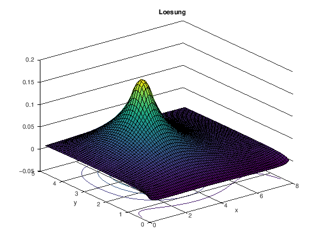

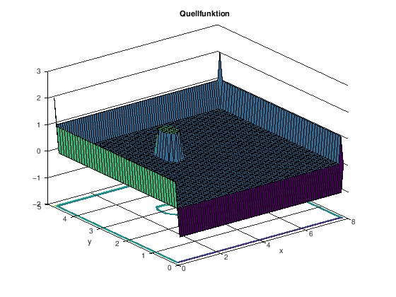

```matlab
%Oeffne ein  Bildfenster und plotte die Lösung auf dem realen Koordinatenfeld
  %-------------------------------------------------
  figure(2);
  surfc(x,y,sol_matrix);
  title ("Loesung");
  ylabel("y")
  xlabel("x")

  %weiteres Bild mit Quellfunktion- rechte Seite des Systems
  figure(3);
  surfc(x,y,f);
  title ("Quellfunktion");
  ylabel("y")
  xlabel("x")
```

### Ergebnis

Bei dem Bild der Quellfunktion sind man den "Hotspot" (Quelldichtefuktion) in der Mitte. Von hier aus startet die Diffusion bis sie zu den Rändern gelangt. Hier sind die Werte am Rand durch die Dirichlet-Randbedingungen vorgegeben, was an den Rändern zu erkennen ist auf dem Bild.

Bei dem Bild der Lösung ist ersichtlich, dass dieTeilchen (Infizierten) vom Ort höherer Konzentration (Quelldichtefunktion) zum Ort niedrigerer Konzentration (Ränder)diffundieren. Je nach vorgegebenen Funktionswerten am Rand verteilen sich die Teilchen unterschiedlich in positive oder negative y-Richtung.

# Implementierung der Randwertaufgabe für Neumann-Randbedingung

Im Nachfolgenden wird die stationäre Diffusion mithilfe der Poissongleichung auf einem rechteckigem Gebiet mithilfe der Finiten Differenzen Methode für Neumann Randwertprobleme implementiert: $$-a\Delta u=f \ \ x \in \ D \ \ $$ $$ \frac{\partial u(x)}{\partial \vec{n}}\equiv \nabla u \cdot \vec{n}=g(x) \quad x \in \partial D$$ Die Neumann-Randbedingungen sagen aus, dass die Werte der Funktion $u(x,y)$ am Rand $x, y \in \partial D$ durch die Richtungsableitung der Funktion $u$ in Richtung des äußeren Normalenvektors gegeben sind.

Im Folgenden wird betrachten wir die Neumann-Randwertaufgabe mit homogenen Randbedingungen: $$ \frac{\partial u(x)}{\partial \vec{n}}\equiv \nabla u \cdot \vec{n}=0 \quad x \in \partial D$$

#### Koordinatenmatrix der Gitterpunkte

```matlab
[x,y]=meshgrid(0:hx:xend,0:hy:yend);  %erweitere die Spalten und Zeilen um 2 weitere Punkte links/rechts bzw oben/ unten für Neumann-Randbedingung
M=size(x)(1);%M=M+2: gibt Anzahl der Zeilen zurück
N=size(x)(2);%N=N+2: gibt Anzahl der Spalten zurück
```

#### Implementation der blocktridiogonalen Systemmatrix $A_h=:BB\in {\mathbb R}^{(N+2)(M+2)\times (N+2)(M+2)}$

[figure not shown]

```matlab
%konstanter Diffusionskoeffizient
a=1.0; %konstanter Diffusionskoeffizient
%--------------------------

% Systemmatrix
%-------------------------------------------
  Vec1=ones(N*M,1); % erzeugt vektor der  Laenge N*M
  BB=diag(-4.*Vec1,0)+diag(ones(N*M-1,1),1)+ diag(ones(N*M-1,1),-1)+diag(ones(N*(M-1),1),N)+diag(ones(N*(M-1),1),-N);
%Systemmatrix N^2xM^2 mit -4 auf der Diagonale und 1 auf den Nebendiagonalen und 1 auf den N und -N-ter Nebendiagonale

%Korrektur der Matrix (Blockdiagonalitaet)
  for  i=1:(M-1)
      BB(i*N+1,i*N)=0;
      BB(i*N,i*N+1)=0;
  endfor

%-------------------------------------------
% Matrix mit Diffkoeff/h^2 multiplizieren
%-------------------------------------------
  BB=BB*a/hx^2;
```

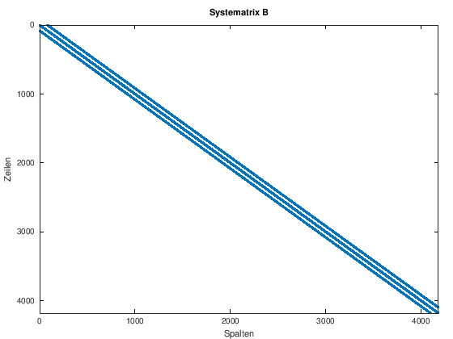

```matlab
% Neumann RB für y:   c* partial_y u=0 - einzelne Blöcke der Matrix ersetzen
 %----------------------------------------------------------------------
  h=hx;
  block=diag((a/h)*ones(N,1)); % da in "In 8" a/hx^2
  %unterer Rand
  BB(1:N,1:N)=block; %setzt linke obere Matrix
  BB(1:N,N+1:2*N)=-block;
  %oberer Rand
  BB(N*(M-1)+1:N*M,N*(M-1)+1:N*M)=block; %setzt rechte untere Matrix
  BB(N*(M-1)+1:N*M,N*(M-2)+1:N*(M-1))=-block;
  %--------------------------
  % Neumann RB für x:  c* partial_x u=0 - einzelne Zeilen der Matrix ersetzen
  %----------------------------------------------------------------------
  %erste Zeile (Vector_up-Linker Rand) werte links
  %letzte Zeile (Vector_down-Rechter Rand)werte rechts
 for i=1:(M-2)
   vector_up=zeros(1,N*M);
   vector_up(N*i+1)=a/h;
   vector_up(N*i+2)=-a/h;
   vector_down=zeros(1,N*M);
   vector_down(N*i+N)=a/h;
   vector_down(N*i+N-1)=-a/h;
   %hier auskommentieren, da sonst linker und rechter Rand auch Neumann wäre, so ist Dirichlet
   %BB(i*N+1,:)=vector_up ;
   %BB(i*N+N,:)=vector_down ;
  endfor



  figure (11);
  %surface (BB);
  spy (BB);
  xlabel("Spalten")
  ylabel("Zeilen")
  zlabel("Matrix B")
  title ("Systematrix B");
```

### Implementation der rechten Seite

```matlab
clear f;
for i=1:N
 for j=1:M
   f(j,i)=1*Quellfunktion(x(j,i),y(j,i));
   %Neumann Randbedingung unten und oben: deswegen an den Rändern Null addiert
   if j==1 f(j,i)=1*Quellfunktion(x(j,i),y(j,i))+0; endif
   if j==M f(j,i)=1*Quellfunktion(x(j,i),y(j,i))+0; endif
   %Dirichlet Randbedingung links und rechts: wegen Neumann braucht nur wert links und nicht noch wert oben und unten, da null
   if (i==1)|| (i==N )
   f(j,i)=1*Quellfunktion(x(j,i),y(j,i))+a*wert_links(j,i,M)/h^2; endif
   endfor
   endfor

  % Ecken-Beiträge: Dirichlet Werte in Ecken beachten
  % durch diese Zeilen setzten Sie in die Ecken die Neumann RB
  % warum es mit Dirichlet RB in den Ecken nicht funktioniert liegt an der Systemmatrix- die Gestalt der ersten und letzten Blockzeile  erlaubt nur die Neumann RB
  %---------------------------------
   f(1,1)=1*Quellfunktion(x(1,1),y(1,1));
   f(1,N)=1*Quellfunktion(x(1,N),y(1,N));
   f(M,1)=1*Quellfunktion(x(M,1),y(M,1));
   f(M,N)=1*Quellfunktion(x(M,N),y(M,N));


  size (f);

  b=-1*reshape(f',N*M,1);
  %reshape funktioniert Spaltenmässig:  es wird Sp1, dann Sp2, usw eingeordnet, wobei wir die Matrix f nach Reihen/Zeilen einordnen.
  %Daher soll die Matrix f' mit N(Zeilen)x M(Spalten) in ein langern Vektor eingeordnet.
```

### Lösung des linearen Gleichungssystems

Die Lösung eines linearen System $Ax=b$ wird in Octave mit dem Befehl 'x=A\b' gefunden.

Danach wird der Lösungsvektor $sol:=\vec{x}_h$ in eine Lösungsmatrix 'sol_matrix' spaltenweise eingeordnet

```matlab
% LOESUNGSSCHRITT
  %-------------------------------------------------
  sol=BB\b;

  sol_matrix=reshape(sol,N,M);% Matrix mit N(Zeilen)x M(Spalten)
  sol_matrix=sol_matrix'; % Transponiert, wegen reshape
```

### Plotten der Lösung

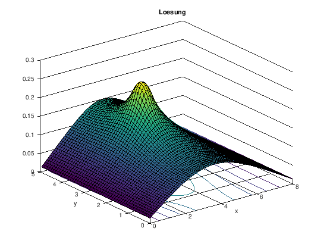

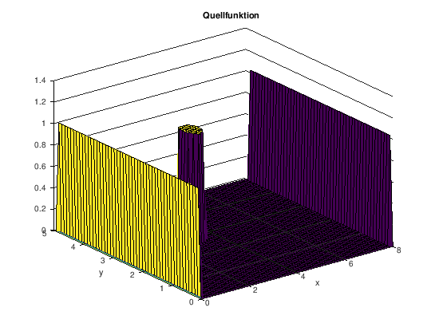

```matlab
%Oeffne ein  Bildfenster und plotte die Lösung auf dem realen Koordinatenfeld
  %-------------------------------------------------
  figure(2);
  surfc(x,y,sol_matrix);
  title ("Loesung");
  ylabel("y")
  xlabel("x")

  %weiteres Bild mit Quellfunktion- rechte Seite des Systems
  figure(3);
  surfc(x,y,f);
  title ("Quellfunktion");
  ylabel("y")
  xlabel("x")
```

### Ergebnis

Teilchen (Infizierten) diffundieren vom Ort höherer Konzentration (Quelldichtefunktion) zum Ort niedrigerer Konzentration (Ränder).  
Die Werte der Funktion u an den Rändern links und rechts sind aufgrund der Dirichlet-Randbedingungen durch Funktionswerte vorgegeben, hingegen sind an dem oberen und unteren Rand die Richtungsableitungen der Funktion $u$ vorgegeben.  
Somit folgt die unterschiedliche Verteilung der Funktion an den Rändern.